# Data frame

Ахмедушка

## Ликбез по типам данных

Перед тем как мы начнем познавать анализ данных, давайте вспомним основные типы данных, которые используются в R:

1. Переменная
2. Массив(вектор)
3. Матрица
4. List
5. Data frame

С переменными и массивами мы работали в 1 семестре, поэтому мы их хорошо усвоили. Про матрицы мы поговорим на факультативе по графам. List иногда бывает полезен, но не будет использоваться в этом курсе. Основным типом данных в нашем курсе будет *data frame* или коротко *df*. Data frame состоит из массивов, а массивы состоят из переменных, поэтому стоит узнать их получше.

## Переменная

Переменная - это самый простой тип данных в R. Вы можете сохранять какое-нибудь значение под определённым названием. Помним, что название должно начинаться с буквы и не содержать пробелов.

Вспомним какие типы переменных бывают в R:

1. Числовой(numeric/integer/double)
2. Строковый(character)
3. Логический(logical)
4. Категориальный или факторный(factor)
5. Дата + время (date)
6. NA(not available)
7. NaN(not a number)

```r
number <- 5
print(number)
## [1] 5
(name <- 'Ahmedushka')
## [1] "Ahmedushka"
(log <- TRUE)
## [1] TRUE
(factor <- factor("Jan"))
## [1] Jan
## Levels: Jan
(date <- Sys.Date())
## [1] "2019-04-18"
(na <- NA)
## [1] NA
(nan <- NaN)
## [1] NaN
```

Класс переменной всегда можно проверить с помощью функций `class()` и `typeof()`.

```r
class(number)
## [1] "numeric"
class(name)
## [1] "character"
class(log)
## [1] "logical"
class(factor)
## [1] "factor"
class(date)
## [1] "Date"
class(na)
## [1] "logical"
class(nan)
## [1] "numeric"
```

Также можно воспользоваться семейством функций `is.*`, чтобы узнать принадлежит ли переменная к опреденному типу.

```r
is.numeric(number)
## [1] TRUE
is.character(name)
## [1] TRUE
is.logical(log)
## [1] TRUE
is.factor(factor)
## [1] TRUE
is.na(na)
## [1] TRUE
```

Про даты и время мы поговорим позже. Вспомним еще семейство функций `as.*`, с помощью которых можно менять тип переменной.

```r
class(number)
## [1] "numeric"
number <- as.character(number)
class(number)
## [1] "character"
```

## Массив

Массив - это упорядоченный набор значений. Основной тип данных, который используется для создания более сложных типов данных. Следует помнить, что массив может содержать переменные только одного типа. Иначе переменные будут принудительно изменены.

```r
numbers <- c(1,4,5,2)
names <- c('Ahmedushka', 'Alex', 'Maksim')
logs <- c(TRUE, FALSE, 1, 0) # логические и числовые типы переменных дружат :3
```

Давайте разбремся зачем нужны факторные переменные. Представьте, что у вас есть массив, в котором записаны названия месяцев.

```r
year1 <- c('Dec', 'Jan', 'Apr', 'Mar')
```

Существует 12 возможных значений. Но при использовании обычного массива у вас возникают 2 проблемы:

1. Возможны опечатки:

```r
year2 <- c('Dec', 'Jam', 'Apr', 'Mar')
```

2. Этот список не сортируется так как нам хотелось бы(сортируется в алфавитном порядке):

```r
sort(year1)
```

```
## [1] "Apr" "Dec" "Jan" "Mar"
```

Эти 2 проблемы можно избежать с помощью факторов:

```r
months <- c('Jan', 'Feb', 'Mar', 'Apr', 'May', 'Jun', 'Jul', 'Aug', 'Sep', 'Oct', 'Nov', 'Dec') # задаем порядок и список допустимых значений
year1_2 <- factor(year1, levels = months)
year2_2 <- factor(year2, levels = months)
```

Если мы совершим ошибку, то выставится значение `NA`. А теперь попробуем отсортировать наш фактор.

```r
sort(year1_2)
```

```
## [1] Jan Mar Apr Dec
## Levels: Jan Feb Mar Apr May Jun Jul Aug Sep Oct Nov Dec
```

## Data Frame

Прежде чем переходить к df, погорим о том, как будут выглядеть для нас данные в этом курсе. Мы будем рассматривать данные “наблюдение - объекты”, их обычно используют в машинном обучении, а также в эконометрике(cross-section). В строках у нас находятся наблюдения. А столбцы это объекты или переменные. К примеру данные про группу людей. Каждое наблюдение это человек, а переменные(объекты) это например фамилия, пол, возраст и так далее. К примеру можно рассмотреть табличку снизу. В ней 4 наблюдения и 4 переменные(имя, возраст, пол, дата рождения).

| Имя | Возраст | Пол | Дата рождения |
| --- | --- | --- | --- |
| Ахмед | 20 | М | 5 мая |
| Виталик | 21 | М | 22 февраля |
| Рита | 20 | Ж | 20 сентября |
| Даша | 20 | Ж | 26 ноября |

Очень важно отметить, что каждая переменная это массив, который имеет определенный тип переменных.

- Имя – Строковый(character)
- Возраст – числовой(numeric/integer/double)
- Пол – факторный(factor)
- Дата рождения – дата + время (date)

А наблюдения имеют разнородные данные. Именно поэтому мы не можем пользоваться матрицами. Матрицы должны содержать данные одного типа.

Давайте создадим наш первый data frame. Для этого нам нужна функция `data.frame`. Создадим табличку выше.

```r
data <- data.frame('Имя' = c('Ахмед', 'Виталик', 'Рита', 'Даша'),
                   'Возраст' = c(20,21,20,20),
                   'Пол' = c('М', 'М', 'Ж', 'Ж'),
                   'Дата рождения' = c('5 мая', '22 февраля', '20 сентября', '26 ноября'))
data
```

| Имя | Возраст | Пол | Дата.рождения |
| --- | --- | --- | --- |
| Ахмед | 20 | М | 5 мая |
| Виталик | 21 | М | 22 февраля |
| Рита | 20 | Ж | 20 сентября |
| Даша | 20 | Ж | 26 ноября |

Заметим, что название переменной “Дата рождения” изменилось на “Дата.рождения”.Это происхоит, потому что data frame запрещает иметь в названии пробелы, а также он запрещает называть переменные с цифр или символов. При создании data frame, мы не делали упор на тип переменных. Мы рассмотрим это позже. Сейчас важно создавать data frame и выполнять с ним основные операции. Чтобы удобно просмотреть, что находится в вашем data frame, можно нажать на него в окошке справа(где находятся все переменные, функции и т.д.) или использовать функцию `View(data)`, где `data` название вашего data frame.

Давайте убедимся, что перед нами правда data frame. Сделаем это с помощью функции `class`.

```r
class(data)
```

```
## [1] "data.frame"
```

Когда вы только начинаете работать с каким-то df, лучше сначала использовать функцию `str`. Она даёт некоторую информации о вашем df.

```r
str(data)
```

```
## 'data.frame':    4 obs. of  4 variables:
##  $ Имя          : Factor w/ 4 levels "Ахмед","Виталик",..: 1 2 4 3
##  $ Возраст      : num  20 21 20 20
##  $ Пол          : Factor w/ 2 levels "Ж","М": 2 2 1 1
##  $ Дата.рождения: Factor w/ 4 levels "20 сентября",..: 4 2 1 3
```

Можно увидеть, что мы имеем дело с df, у которого 4 наблюдения и 4 переменные, а также информацию по каждому столбцу(переменной). После названия столбца(переменной) идет тип переменных в нем. Заметим, что переменные имя, пол и дата рождения имеют факторный тип переменных. Так происходит из-за параметра `stringAsFactors`. Давайте выставим `FALSE` и посмотрим на данные заново.

```r
data <- data.frame('Имя' = c('Ахмед', 'Виталик', 'Рита', 'Даша'),
                   'Возраст' = c(20,21,20,20),
                   'Пол' = c('М', 'М', 'Ж', 'Ж'),
                   'Дата рождения' = c('5 мая', '22 февраля', '20 сентября', '26 ноября'),
                   stringsAsFactors = FALSE)
str(data)
```

```
## 'data.frame':    4 obs. of  4 variables:
##  $ Имя          : chr  "Ахмед" "Виталик" "Рита" "Даша"
##  $ Возраст      : num  20 21 20 20
##  $ Пол          : chr  "М" "М" "Ж" "Ж"
##  $ Дата.рождения: chr  "5 мая" "22 февраля" "20 сентября" "26 ноября"
```

Теперь наши переменные являются строковыми(character). Пока что не обращаем внимание на то, что пол не имеет факторный тип переменных, а дата рождения не является датой. В R и его пакетах есть встроенные датасеты(df). Давайте воспользуемся датасетом `mtcars`. Об этом датасете можно подробнее прочитать с помощью команды `?mtcars`. Этот датасет о характеристиках машин 1974 года. Для начала изучим структура датасета и найдем его размерность с помощью функции `dim`.

```r
str(mtcars)
```

```
## 'data.frame':    32 obs. of  11 variables:
##  $ mpg : num  21 21 22.8 21.4 18.7 18.1 14.3 24.4 22.8 19.2 ...
##  $ cyl : num  6 6 4 6 8 6 8 4 4 6 ...
##  $ disp: num  160 160 108 258 360 ...
##  $ hp  : num  110 110 93 110 175 105 245 62 95 123 ...
##  $ drat: num  3.9 3.9 3.85 3.08 3.15 2.76 3.21 3.69 3.92 3.92 ...
##  $ wt  : num  2.62 2.88 2.32 3.21 3.44 ...
##  $ qsec: num  16.5 17 18.6 19.4 17 ...
##  $ vs  : num  0 0 1 1 0 1 0 1 1 1 ...
##  $ am  : num  1 1 1 0 0 0 0 0 0 0 ...
##  $ gear: num  4 4 4 3 3 3 3 4 4 4 ...
##  $ carb: num  4 4 1 1 2 1 4 2 2 4 ...
```

```r
dim(mtcars)
```

```
## [1] 32 11
```

Видим, что имеется 32 наблюдения и 11 переменных, все из которых числовые. Когда df очень большой неудобно просматривать его весь. Обычно смотрят на первые и последние 6 наблюдений с помощью функций `head` и `tail`. Можно выводить не 6 а другое количество наблюдений на экран с помощью парметра `n`.

```r
head(mtcars)
```

|  | mpg | cyl | disp | hp | drat | wt | qsec | vs | am | gear | carb |
| --- | --- | --- | --- | --- | --- | --- | --- | --- | --- | --- | --- |
| Mazda RX4 | 21.0 | 6 | 160 | 110 | 3.90 | 2.620 | 16.46 | 0 | 1 | 4 | 4 |
| Mazda RX4 Wag | 21.0 | 6 | 160 | 110 | 3.90 | 2.875 | 17.02 | 0 | 1 | 4 | 4 |
| Datsun 710 | 22.8 | 4 | 108 | 93 | 3.85 | 2.320 | 18.61 | 1 | 1 | 4 | 1 |
| Hornet 4 Drive | 21.4 | 6 | 258 | 110 | 3.08 | 3.215 | 19.44 | 1 | 0 | 3 | 1 |
| Hornet Sportabout | 18.7 | 8 | 360 | 175 | 3.15 | 3.440 | 17.02 | 0 | 0 | 3 | 2 |
| Valiant | 18.1 | 6 | 225 | 105 | 2.76 | 3.460 | 20.22 | 1 | 0 | 3 | 1 |

```r
tail(mtcars, n = 3)
```

|  | mpg | cyl | disp | hp | drat | wt | qsec | vs | am | gear | carb |
| --- | --- | --- | --- | --- | --- | --- | --- | --- | --- | --- | --- |
| Ferrari Dino | 19.7 | 6 | 145 | 175 | 3.62 | 2.77 | 15.5 | 0 | 1 | 5 | 6 |
| Maserati Bora | 15.0 | 8 | 301 | 335 | 3.54 | 3.57 | 14.6 | 0 | 1 | 5 | 8 |
| Volvo 142E | 21.4 | 4 | 121 | 109 | 4.11 | 2.78 | 18.6 | 1 | 1 | 4 | 2 |

Data frame очень похож на матрицу. Он тоже двумерный, поэтому к нему можно обращаться как к матрице. Давайте найдем значение в 1 строке(наблюдении), во 2 столбце(переменной). Выведем полностью 1 строку(наблюдение) и 3 столбец(переменную).

```r
mtcars[1, 2]
```

```
## [1] 6
```

```r
mtcars[1, ]
```

|  | mpg | cyl | disp | hp | drat | wt | qsec | vs | am | gear | carb |
| --- | --- | --- | --- | --- | --- | --- | --- | --- | --- | --- | --- |
| Mazda RX4 | 21 | 6 | 160 | 110 | 3.9 | 2.62 | 16.46 | 0 | 1 | 4 | 4 |

```r
mtcars[, 3]
```

```
##  [1] 160.0 160.0 108.0 258.0 360.0 225.0 360.0 146.7 140.8 167.6 167.6
## [12] 275.8 275.8 275.8 472.0 460.0 440.0  78.7  75.7  71.1 120.1 318.0
## [23] 304.0 350.0 400.0  79.0 120.3  95.1 351.0 145.0 301.0 121.0
```

Можно получать срезы. Например мне нужны 1-3 наблюдения и 2-4 переменные.

```r
mtcars[1:3,2:4]
```

|  | cyl | disp | hp |
| --- | --- | --- | --- |
| Mazda RX4 | 6 | 160 | 110 |
| Mazda RX4 Wag | 6 | 160 | 110 |
| Datsun 710 | 4 | 108 | 93 |

Чтобы получить полный список названий переменных, можно использовать функцию `names`. На выходе вы получите массив имен.

```r
names(mtcars)
```

```
##  [1] "mpg"  "cyl"  "disp" "hp"   "drat" "wt"   "qsec" "vs"   "am"   "gear"
## [11] "carb"
```

Переменные можно выбирать и с помощью имени.

```r
mtcars[1:3,"disp"]
```

```
## [1] 160 160 108
```

Или это можно сделать с помощью знака `$`. После него можно нажать кнопку *TAB* и увидеть всевозможнные варианты.

```r
mtcars$wt
```

```
##  [1] 2.620 2.875 2.320 3.215 3.440 3.460 3.570 3.190 3.150 3.440 3.440
## [12] 4.070 3.730 3.780 5.250 5.424 5.345 2.200 1.615 1.835 2.465 3.520
## [23] 3.435 3.840 3.845 1.935 2.140 1.513 3.170 2.770 3.570 2.780
```

Можно увидеть сводную статистику по каждой переменной с помощью функции `summary`.

```r
summary(mtcars)
```

```
##       mpg             cyl             disp             hp
##  Min.   :10.40   Min.   :4.000   Min.   : 71.1   Min.   : 52.0
##  1st Qu.:15.43   1st Qu.:4.000   1st Qu.:120.8   1st Qu.: 96.5
##  Median :19.20   Median :6.000   Median :196.3   Median :123.0
##  Mean   :20.09   Mean   :6.188   Mean   :230.7   Mean   :146.7
##  3rd Qu.:22.80   3rd Qu.:8.000   3rd Qu.:326.0   3rd Qu.:180.0
##  Max.   :33.90   Max.   :8.000   Max.   :472.0   Max.   :335.0
##       drat             wt             qsec             vs
##  Min.   :2.760   Min.   :1.513   Min.   :14.50   Min.   :0.0000
##  1st Qu.:3.080   1st Qu.:2.581   1st Qu.:16.89   1st Qu.:0.0000
##  Median :3.695   Median :3.325   Median :17.71   Median :0.0000
##  Mean   :3.597   Mean   :3.217   Mean   :17.85   Mean   :0.4375
##  3rd Qu.:3.920   3rd Qu.:3.610   3rd Qu.:18.90   3rd Qu.:1.0000
##  Max.   :4.930   Max.   :5.424   Max.   :22.90   Max.   :1.0000
##        am              gear            carb
##  Min.   :0.0000   Min.   :3.000   Min.   :1.000
##  1st Qu.:0.0000   1st Qu.:3.000   1st Qu.:2.000
##  Median :0.0000   Median :4.000   Median :2.000
##  Mean   :0.4062   Mean   :3.688   Mean   :2.812
##  3rd Qu.:1.0000   3rd Qu.:4.000   3rd Qu.:4.000
##  Max.   :1.0000   Max.   :5.000   Max.   :8.000
```

Переменная `cyl` показывает количество цилиндров в машине. Можно увидеть сколько наблюдений приходится на определенное количество цилиндров с помощью функции `table`.

```r
table(mtcars$cyl)
```

```
##
##  4  6  8
## 11  7 14
```

## Tibble

Функция `data.frame` была придумана 10-20 лет назад. Но мир не стоит на месте. R развивается, многие функции улучшаются и оптимизируются. Сейчас все пользуются функцией `tibble` для создания df. Данная функция находится в одноименном пакете `tibble`. Удалить функцию `data.frame` нельзя, потому что можно поставить работоспособность существующего кода. Я советую пользоваться `tibble`, так как мы будем работать с библиотекой `tidyverse`, в которой все пакеты взаимосвязаны и предназначены для работы с `tibble`. Давайте подгрузим пакет.

```r
# install.packages('tibble')
library('tibble')
```

У `tibble` есть красивая справка. Её можно вызвать с помощью команды `vignette('tibble')`. Давайте создадим первый df.

```r
df <- tibble(
        x = 1:5,
        y = 1,
        c = 'a',
        z = x^2 + y,
        `:)` = 10,
        ` ` = NA
      )
df
```

| x | y | c | z | :) |  |
| --- | --- | --- | --- | --- | --- |
| 1 | 1 | a | 2 | 10 | NA |
| 2 | 1 | a | 5 | 10 | NA |
| 3 | 1 | a | 10 | 10 | NA |
| 4 | 1 | a | 17 | 10 | NA |
| 5 | 1 | a | 26 | 10 | NA |

```r
str(df)
```

```
## Classes 'tbl_df', 'tbl' and 'data.frame':    5 obs. of  6 variables:
##  $ x : int  1 2 3 4 5
##  $ y : num  1 1 1 1 1
##  $ c : chr  "a" "a" "a" "a" ...
##  $ z : num  2 5 10 17 26
##  $ :): num  10 10 10 10 10
##  $   : logi  NA NA NA NA NA
```

Заметим некоторые отличия от функции `data.frame`:

- Можно ссылаться на уже созданные переменные(переменная `z`).
- С помощью ` можно давать любые названия переменным.
- При отображении `tibble` под названиями переменных появляется тип переменных.
- Для удобного отображения появляются только первые 10 наблюдений и все переменные, которые помещаются в пределах экрана.

Также бывает удобным задавать `tibble` в виде таблицы. Для этого можно использовать функцию `tribble`. Давайте попробуем.

```r
df1 <- tribble(
        ~x, ~y, ~z,
        #--|--|---
        "a", 2, 3.6,
        "b", 1, 8.5
       )
df1
```

| x | y | z |
| --- | --- | --- |
| a | 2 | 3.6 |
| b | 1 | 8.5 |

Часто некоторые базовые функции не работают с `tibble` или некоторые функции из пакетов не очень хорошо работают с `data.frame`. В таких случаях вы можете перевести `tibble` в `data.frame` и наоборот с помощью функций `as_tibble` и `as.data.frame`.

```r
as_tibble(mtcars)
```

| mpg | cyl | disp | hp | drat | wt | qsec | vs | am | gear | carb |
| --- | --- | --- | --- | --- | --- | --- | --- | --- | --- | --- |
| 21.0 | 6 | 160.0 | 110 | 3.90 | 2.620 | 16.46 | 0 | 1 | 4 | 4 |
| 21.0 | 6 | 160.0 | 110 | 3.90 | 2.875 | 17.02 | 0 | 1 | 4 | 4 |
| 22.8 | 4 | 108.0 | 93 | 3.85 | 2.320 | 18.61 | 1 | 1 | 4 | 1 |
| 21.4 | 6 | 258.0 | 110 | 3.08 | 3.215 | 19.44 | 1 | 0 | 3 | 1 |
| 18.7 | 8 | 360.0 | 175 | 3.15 | 3.440 | 17.02 | 0 | 0 | 3 | 2 |
| 18.1 | 6 | 225.0 | 105 | 2.76 | 3.460 | 20.22 | 1 | 0 | 3 | 1 |
| 14.3 | 8 | 360.0 | 245 | 3.21 | 3.570 | 15.84 | 0 | 0 | 3 | 4 |
| 24.4 | 4 | 146.7 | 62 | 3.69 | 3.190 | 20.00 | 1 | 0 | 4 | 2 |
| 22.8 | 4 | 140.8 | 95 | 3.92 | 3.150 | 22.90 | 1 | 0 | 4 | 2 |
| 19.2 | 6 | 167.6 | 123 | 3.92 | 3.440 | 18.30 | 1 | 0 | 4 | 4 |

[output cut: 22 more lines]

```r
as.data.frame(df)
```

| x | y | c | z | :) |  |
| --- | --- | --- | --- | --- | --- |
| 1 | 1 | a | 2 | 10 | NA |
| 2 | 1 | a | 5 | 10 | NA |
| 3 | 1 | a | 10 | 10 | NA |
| 4 | 1 | a | 17 | 10 | NA |
| 5 | 1 | a | 26 | 10 | NA |

## Первичная визуализация

Для того, чтобы быстро посмотреть на распределение(гистограмму) какой-то переменной можно использовать функцию `hist`.

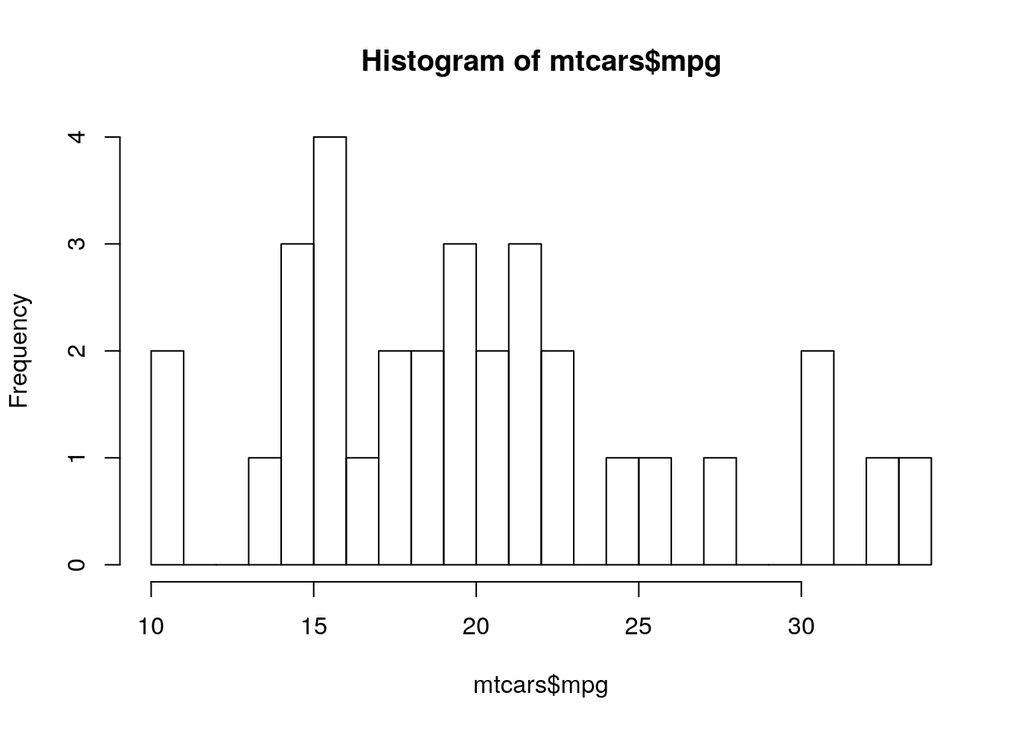

```r
hist(mtcars$mpg, breaks = 30)
```

Если же вы хотите быстро посомтреть на зависимость одной переменной от другой можно использовать обычную функцию `plot`.

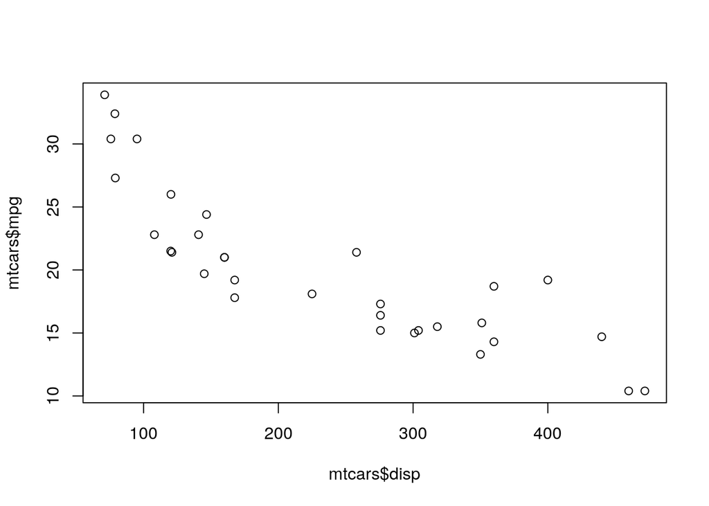

```r
plot(mtcars$disp, mtcars$mpg)
```

Данные рисунки используются для быстрой визуализации. Скоро мы изучим пакет `ggplot2` для более продвинутой и красивой визуализации.

## Изменение типа переменных

Для изменения типа переменных используется семейство функций `as.*`.

- `as.integer`
- `as.numeric`
- `as.character`
- `as.factor`
- `as.Date`
- `as.POSIXct`
- `as.logical`

Работу с датами мы будем обсуждать позже с помощью пакета `lubridate`.

```r
df <- tibble(
        x = c('1', '2', '3', '4'),
        y = c(10, 20, 30, 40),
        z = c(1,0,1,0),
        s = c('M','F', 'M', 'F')
      )
df
```

| x | y | z | s |
| --- | --- | --- | --- |
| 1 | 10 | 1 | M |
| 2 | 20 | 0 | F |
| 3 | 30 | 1 | M |
| 4 | 40 | 0 | F |

```r
str(df)
```

```
## Classes 'tbl_df', 'tbl' and 'data.frame':    4 obs. of  4 variables:
##  $ x: chr  "1" "2" "3" "4"
##  $ y: num  10 20 30 40
##  $ z: num  1 0 1 0
##  $ s: chr  "M" "F" "M" "F"
```

```r
df$x <- as.numeric(df$x)
df$y <- as.character(df$y)
df$z <- as.logical(df$z)
df$s <- as.factor(df$s)
df
```

| x | y | z | s |
| --- | --- | --- | --- |
| 1 | 10 | TRUE | M |
| 2 | 20 | FALSE | F |
| 3 | 30 | TRUE | M |
| 4 | 40 | FALSE | F |

```r
str(df)
```

```
## Classes 'tbl_df', 'tbl' and 'data.frame':    4 obs. of  4 variables:
##  $ x: num  1 2 3 4
##  $ y: chr  "10" "20" "30" "40"
##  $ z: logi  TRUE FALSE TRUE FALSE
##  $ s: Factor w/ 2 levels "F","M": 2 1 2 1
```